# Analisis strip-split-plot del rendimiento de arroz

Dr. Byron González

# Analisis strip-split-plot del rendimiento de arroz

Este documento presenta un flujo reproducible para analizar el rendimiento de arroz con el conjunto de datos `gomez.stripsplitplot` del paquete `agridat`. El experimento corresponde a un arreglo **strip-split-plot**: las variedades (`gen`) se asignan a franjas en una direccion, las dosis de nitrogeno (`nitro`) a franjas perpendiculares y los metodos de plantacion (`planting`) a las intersecciones de ambas franjas.

El analisis sigue el modelo de Gomez y Gomez (1984), ajustado con `aov()` y su estructura de errores. Las comparaciones multiples se obtienen con `emmeans` y letras de agrupamiento compacto para las interacciones que interesan: `gen:nitro` y `gen:planting`.

**Profesor:** Dr. Byron González

## Tabla de contenido

- Objetivo y estructura experimental
- 1. Instalar y cargar paquetes
- 2. Cargar y revisar los datos
- 3. Preparar los factores
- 4. Visualizar el croquis de campo
- 5. Ajustar el modelo strip-split-plot
- 6. Obtener el resumen del ANOVA
- 7. Comparar `gen:nitro`
- 8. Comparar `gen:planting`
- 9. Interpretar y reportar los resultados
- Referencias

## Objetivo y estructura experimental

La respuesta es `yield`, el rendimiento observado en cada unidad experimental. Las variables tienen la siguiente funcion:

| Variable | Funcion en el diseno |
| --- | --- |
| `rep` | Repeticion o bloque del experimento |
| `gen` | Variedad, asignada a franjas en una direccion |
| `nitro` | Nivel de nitrogeno, asignado a franjas perpendiculares |
| `planting` | Metodo de plantacion, asignado a las intersecciones |
| `yield` | Rendimiento de arroz |

En un strip-split-plot no todas las fuentes de variacion tienen el mismo error experimental. Por eso no se debe analizar el experimento como si fuera un factorial completamente aleatorizado con un unico error residual. La clausula `Error()` de `aov()` representa los estratos asociados con las repeticiones, las franjas y sus combinaciones.

## 1. Instalar y cargar paquetes

Este chunk instala los paquetes que no esten disponibles y luego los carga. `agridat` proporciona los datos de ejemplo; `emmeans` calcula medias marginales estimadas; `multcomp` genera las letras de agrupamiento; y `desplot` permite dibujar el croquis del campo.

```r
paquetes <- c("agridat", "emmeans", "multcomp", "desplot")
nuevos <- paquetes[!vapply(paquetes, requireNamespace, logical(1), quietly = TRUE)]

if (length(nuevos) > 0) {
  install.packages(nuevos)
}

library(agridat)
library(emmeans)
library(multcomp)
library(desplot)
```

La instalacion solo debe ejecutarse cuando sea necesaria. En un servidor de GitHub Actions o en otro entorno automatizado, es preferible instalar las dependencias en una etapa separada y dejar el documento dedicado al analisis.

## 2. Cargar y revisar los datos

El siguiente chunk carga `gomez.stripsplitplot` y crea una copia de trabajo llamada `dat`. Las inspecciones iniciales permiten comprobar los nombres de las columnas, el tipo de cada variable y la cantidad de observaciones por combinacion experimental.

```r
data(gomez.stripsplitplot, package = "agridat")
dat <- gomez.stripsplitplot

str(dat)
head(dat)
summary(dat)

with(dat, table(rep, gen, nitro, planting))
```

```
## 'data.frame':    108 obs. of  7 variables:
##  $ yield   : int  2373 4007 2620 2726 4447 2572 4076 5630 4676 4838 ...
##  $ planting: Factor w/ 2 levels "P1","P2": 1 1 1 1 1 1 1 1 1 1 ...
##  $ rep     : Factor w/ 3 levels "R1","R2","R3": 1 1 1 1 1 1 1 1 1 1 ...
##  $ nitro   : int  0 0 0 0 0 0 60 60 60 60 ...
##  $ gen     : Factor w/ 6 levels "G1","G2","G3",..: 1 2 3 4 5 6 1 2 3 4 ...
##  $ col     : int  1 1 1 1 1 1 3 3 3 3 ...
##  $ row     : int  2 6 8 3 9 11 1 6 7 3 ...
##   yield planting rep nitro gen col row
## 1  2373       P1  R1     0  G1   1   2
## 2  4007       P1  R1     0  G2   1   6
## 3  2620       P1  R1     0  G3   1   8
## 4  2726       P1  R1     0  G4   1   3
## 5  4447       P1  R1     0  G5   1   9
## 6  2572       P1  R1     0  G6   1  11
##      yield      planting rep         nitro     gen          col
##  Min.   :1556   P1:54    R1:36   Min.   :  0   G1:18   Min.   :1
##  1st Qu.:4290   P2:54    R2:36   1st Qu.:  0   G2:18   1st Qu.:3
##  Median :5043            R3:36   Median : 60   G3:18   Median :5
##  Mean   :5372                    Mean   : 60   G4:18   Mean   :5
##  3rd Qu.:6826                    3rd Qu.:120   G5:18   3rd Qu.:7
##  Max.   :9838                    Max.   :120   G6:18   Max.   :9
##       row
##  Min.   : 1.00
##  1st Qu.: 3.75
##  Median : 6.50
##  Mean   : 6.50
##  3rd Qu.: 9.25
##  Max.   :12.00
## , , nitro = 0, planting = P1
##
##     gen
## rep  G1 G2 G3 G4 G5 G6
##   R1  1  1  1  1  1  1
##   R2  1  1  1  1  1  1
##   R3  1  1  1  1  1  1
##
## , , nitro = 60, planting = P1
##
##     gen
```

[output cut: 21 more lines]

```
## , , nitro = 60, planting = P2
##
##     gen
## rep  G1 G2 G3 G4 G5 G6
##   R1  1  1  1  1  1  1
##   R2  1  1  1  1  1  1
##   R3  1  1  1  1  1  1
##
## , , nitro = 120, planting = P2
##
##     gen
## rep  G1 G2 G3 G4 G5 G6
##   R1  1  1  1  1  1  1
##   R2  1  1  1  1  1  1
##   R3  1  1  1  1  1  1
```

Antes de ajustar el modelo, hay que verificar que cada combinacion prevista exista y que las repeticiones esten correctamente identificadas. La tabla de frecuencias tambien ayuda a detectar datos faltantes o celdas con diferente numero de observaciones.

## 3. Preparar los factores

Aunque `nitro` puede aparecer como variable numerica, en este experimento representa niveles discretos de tratamiento. Debe tratarse como factor para que el modelo estime una media por nivel y no una tendencia lineal impuesta por los valores numericos.

```r
dat <- transform(
  dat,
  rep = factor(rep),
  gen = factor(gen),
  nf = factor(nitro),
  planting = factor(planting)
)

str(dat)
```

```
## 'data.frame':    108 obs. of  8 variables:
##  $ yield   : int  2373 4007 2620 2726 4447 2572 4076 5630 4676 4838 ...
##  $ planting: Factor w/ 2 levels "P1","P2": 1 1 1 1 1 1 1 1 1 1 ...
##  $ rep     : Factor w/ 3 levels "R1","R2","R3": 1 1 1 1 1 1 1 1 1 1 ...
##  $ nitro   : int  0 0 0 0 0 0 60 60 60 60 ...
##  $ gen     : Factor w/ 6 levels "G1","G2","G3",..: 1 2 3 4 5 6 1 2 3 4 ...
##  $ col     : int  1 1 1 1 1 1 3 3 3 3 ...
##  $ row     : int  2 6 8 3 9 11 1 6 7 3 ...
##  $ nf      : Factor w/ 3 levels "0","60","120": 1 1 1 1 1 1 2 2 2 2 ...
```

Se conserva `nitro` para identificar los niveles originales y se crea `nf` como el factor que entra en el modelo. Esta conversion es importante porque las interacciones `gen:nf` y `gen:planting` deben representar combinaciones de tratamientos, no pendientes numericas.

## 4. Visualizar el croquis de campo

El croquis permite comprobar la asignacion espacial de los tratamientos. En `desplot()`, `gen` y `nitro` se muestran como franjas, mientras que `planting` se escribe en las intersecciones.

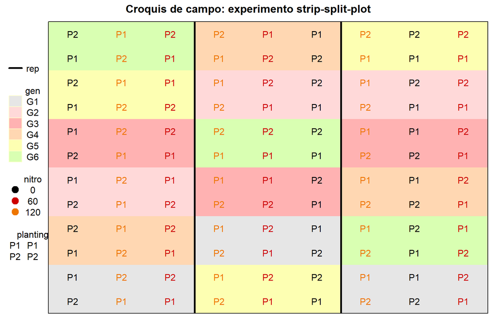

Croquis de campo del experimento strip-split-plot.

```r
desplot(
  dat,
  gen ~ col * row,
  out1 = rep,
  col = nitro,
  text = planting,
  cex = 1,
  main = "Croquis de campo: experimento strip-split-plot"
)
```

`out1 = rep` separa visualmente las repeticiones. `col = nitro` colorea las franjas de nitrogeno y `text = planting` etiqueta el tratamiento de plantacion en cada interseccion. Esta figura no sustituye al modelo, pero sirve para validar que la estructura declarada en `Error()` corresponde al arreglo experimental.

## 5. Ajustar el modelo strip-split-plot

El modelo se ajusta con la formula factorial completa `gen * nf * planting`, que incluye los tres efectos principales, las tres interacciones de dos factores y la interaccion triple. La parte `Error()` especifica los estratos de aleatorizacion del diseño.

```r
m1 <- aov(
  yield ~ gen * nf * planting +
    Error(rep + rep:nf + rep:gen + rep:nf:gen),
  data = dat
)
```

La formula debe mantenerse vinculada al modo en que se aleatorizaron los tratamientos. Cambiarla por un modelo con un unico residual puede producir pruebas F y errores estandar incorrectos para algunas fuentes.

## 6. Obtener el resumen del ANOVA

`summary(m1)` imprime el resumen de cada estrato de error creado por `aov()`. Es normal recibir varios bloques de resultados en lugar de una sola tabla, porque cada bloque corresponde a una escala distinta de aleatorizacion.

```r
summary(m1)
```

```
##
## Error: rep
##           Df   Sum Sq Mean Sq F value Pr(>F)
## Residuals  2 15289498 7644749
##
## Error: rep:nf
##           Df    Sum Sq  Mean Sq F value  Pr(>F)
## nf         2 116489166 58244583   36.62 0.00268 **
## Residuals  4   6361491  1590373
## ---
## Signif. codes:  0 '***' 0.001 '**' 0.01 '*' 0.05 '.' 0.1 ' ' 1
##
## Error: rep:gen
##           Df   Sum Sq Mean Sq F value Pr(>F)
## gen        5 49119270 9823854   3.676 0.0379 *
## Residuals 10 26721828 2672183
## ---
## Signif. codes:  0 '***' 0.001 '**' 0.01 '*' 0.05 '.' 0.1 ' ' 1
##
## Error: rep:nf:gen
##           Df   Sum Sq Mean Sq F value Pr(>F)
## gen:nf    10 24595731 2459573   2.575 0.0344 *
## Residuals 20 19106733  955337
## ---
## Signif. codes:  0 '***' 0.001 '**' 0.01 '*' 0.05 '.' 0.1 ' ' 1
##
## Error: Within
##                 Df   Sum Sq Mean Sq F value   Pr(>F)
## planting         1   723079  723079   1.715   0.1986
## gen:planting     5 23761441 4752288  11.271 1.37e-06 ***
## nf:planting      2  2468132 1234066   2.927   0.0664 .
## gen:nf:planting 10  7512072  751207   1.782   0.1000 .
## Residuals       36 15179354  421649
## ---
## Signif. codes:  0 '***' 0.001 '**' 0.01 '*' 0.05 '.' 0.1 ' ' 1
```

La lectura debe comenzar por los efectos principales y las interacciones en el estrato que les corresponde. Si una interaccion es significativa, sus medias marginales deben examinarse antes de interpretar los efectos principales. En particular, una interaccion significativa `gen:nf` indica que la respuesta de las variedades cambia segun el nivel de nitrogeno; una interaccion significativa `gen:planting` indica que el metodo de plantacion no tiene el mismo comportamiento en todas las variedades.

Para conservar el resumen en un objeto y facilitar un reporte posterior:

```r
anova_m1 <- summary(m1)
anova_m1
```

```
##
## Error: rep
##           Df   Sum Sq Mean Sq F value Pr(>F)
## Residuals  2 15289498 7644749
##
## Error: rep:nf
##           Df    Sum Sq  Mean Sq F value  Pr(>F)
## nf         2 116489166 58244583   36.62 0.00268 **
## Residuals  4   6361491  1590373
## ---
## Signif. codes:  0 '***' 0.001 '**' 0.01 '*' 0.05 '.' 0.1 ' ' 1
##
## Error: rep:gen
##           Df   Sum Sq Mean Sq F value Pr(>F)
## gen        5 49119270 9823854   3.676 0.0379 *
## Residuals 10 26721828 2672183
## ---
## Signif. codes:  0 '***' 0.001 '**' 0.01 '*' 0.05 '.' 0.1 ' ' 1
##
## Error: rep:nf:gen
##           Df   Sum Sq Mean Sq F value Pr(>F)
## gen:nf    10 24595731 2459573   2.575 0.0344 *
## Residuals 20 19106733  955337
## ---
## Signif. codes:  0 '***' 0.001 '**' 0.01 '*' 0.05 '.' 0.1 ' ' 1
##
## Error: Within
##                 Df   Sum Sq Mean Sq F value   Pr(>F)
## planting         1   723079  723079   1.715   0.1986
## gen:planting     5 23761441 4752288  11.271 1.37e-06 ***
## nf:planting      2  2468132 1234066   2.927   0.0664 .
## gen:nf:planting 10  7512072  751207   1.782   0.1000 .
## Residuals       36 15179354  421649
## ---
## Signif. codes:  0 '***' 0.001 '**' 0.01 '*' 0.05 '.' 0.1 ' ' 1
```

## 7. Comparar `gen:nitro`

Las medias marginales estimadas para cada combinacion de variedad y nitrogeno se solicitan con `emmeans(m1, ~ gen * nf)`. `emmeans` usa el modelo ajustado y, por tanto, respeta la informacion disponible y los ajustes del modelo en lugar de calcular solamente promedios aritmeticos sin contexto.

```r
means_gen_nf <- emmeans(m1, ~ gen * nf)
means_gen_nf
```

```
##  gen nf  emmean  SE df lower.CL upper.CL
##  G1  0     3179 559 21     2017     4341
##  G2  0     4718 559 21     3555     5880
##  G3  0     4295 559 21     3133     5457
##  G4  0     4615 559 21     3453     5777
##  G5  0     3916 559 21     2754     5078
##  G6  0     3858 559 21     2696     5021
##  G1  60    5058 559 21     3895     6220
##  G2  60    6112 559 21     4949     7274
##  G3  60    6178 559 21     5015     7340
##  G4  60    5549 559 21     4387     6712
##  G5  60    5203 559 21     4041     6365
##  G6  60    4168 559 21     3005     5330
##  G1  120   7236 559 21     6074     8398
##  G2  120   6910 559 21     5747     8072
##  G3  120   7792 559 21     6630     8955
##  G4  120   7486 559 21     6324     8649
##  G5  120   6014 559 21     4851     7176
##  G6  120   4406 559 21     3244     5568
##
## Results are averaged over the levels of: planting
## Warning: EMMs are biased unless design is perfectly balanced
## Confidence level used: 0.95
```

Primero es recomendable obtener la tabla de contrastes pareados con ajuste por multiplicidad:

```r
pairs_gen_nf <- pairs(means_gen_nf, adjust = "tukey")
pairs_gen_nf
```

```
##  contrast            estimate  SE   df t.ratio p.value
##  G1 nf0 - G2 nf0      -1538.7 714 23.4  -2.156  0.7613
##  G1 nf0 - G3 nf0      -1116.0 714 23.4  -1.564  0.9738
##  G1 nf0 - G4 nf0      -1435.8 714 23.4  -2.012  0.8365
##  G1 nf0 - G5 nf0       -736.8 714 23.4  -1.033  0.9997
##  G1 nf0 - G6 nf0       -679.5 714 23.4  -0.952  0.9999
##  G1 nf0 - G1 nf60     -1878.5 595 22.9  -3.158  0.2120
##  G1 nf0 - G2 nf60     -2932.7 738 24.6  -3.974  0.0402
##  G1 nf0 - G3 nf60     -2998.7 738 24.6  -4.064  0.0330
##  G1 nf0 - G4 nf60     -2370.3 738 24.6  -3.212  0.1882
##  G1 nf0 - G5 nf60     -2024.0 738 24.6  -2.743  0.4027
##  G1 nf0 - G6 nf60      -988.5 738 24.6  -1.340  0.9941
##  G1 nf0 - G1 nf120    -4057.2 595 22.9  -6.822  0.0001
##  G1 nf0 - G2 nf120    -3730.7 738 24.6  -5.056  0.0033
##  G1 nf0 - G3 nf120    -4613.3 738 24.6  -6.252  0.0002
##  G1 nf0 - G4 nf120    -4307.5 738 24.6  -5.838  0.0005
##  G1 nf0 - G5 nf120    -2834.5 738 24.6  -3.841  0.0537
##  G1 nf0 - G6 nf120    -1227.2 738 24.6  -1.663  0.9571
##  G2 nf0 - G3 nf0        422.7 714 23.4   0.592  1.0000
##  G2 nf0 - G4 nf0        102.8 714 23.4   0.144  1.0000
##  G2 nf0 - G5 nf0        801.8 714 23.4   1.124  0.9991
##  G2 nf0 - G6 nf0        859.2 714 23.4   1.204  0.9981
##  G2 nf0 - G1 nf60      -339.8 738 24.6  -0.461  1.0000
##  G2 nf0 - G2 nf60     -1394.0 595 22.9  -2.344  0.6491
##  G2 nf0 - G3 nf60     -1460.0 738 24.6  -1.979  0.8531
##  G2 nf0 - G4 nf60      -831.7 738 24.6  -1.127  0.9991
##  G2 nf0 - G5 nf60      -485.3 738 24.6  -0.658  1.0000
##  G2 nf0 - G6 nf60       550.2 738 24.6   0.746  1.0000
##  G2 nf0 - G1 nf120    -2518.5 738 24.6  -3.413  0.1291
##  G2 nf0 - G2 nf120    -2192.0 595 22.9  -3.686  0.0786
##  G2 nf0 - G3 nf120    -3074.7 738 24.6  -4.167  0.0262
##  G2 nf0 - G4 nf120    -2768.8 738 24.6  -3.752  0.0649
##  G2 nf0 - G5 nf120    -1295.8 738 24.6  -1.756  0.9345
##  G2 nf0 - G6 nf120      311.5 738 24.6   0.422  1.0000
##  G3 nf0 - G4 nf0       -319.8 714 23.4  -0.448  1.0000
##  G3 nf0 - G5 nf0        379.2 714 23.4   0.531  1.0000
##  G3 nf0 - G6 nf0        436.5 714 23.4   0.612  1.0000
##  G3 nf0 - G1 nf60      -762.5 738 24.6  -1.033  0.9997
##  G3 nf0 - G2 nf60     -1816.7 738 24.6  -2.462  0.5742
##  G3 nf0 - G3 nf60     -1882.7 595 22.9  -3.165  0.2094
```

[output cut: 102 more lines]

```
##  G1 nf120 - G5 nf120   1222.7 714 23.4   1.713  0.9448
##  G1 nf120 - G6 nf120   2830.0 714 23.4   3.966  0.0430
##  G2 nf120 - G3 nf120   -882.7 714 23.4  -1.237  0.9974
##  G2 nf120 - G4 nf120   -576.8 714 23.4  -0.808  1.0000
##  G2 nf120 - G5 nf120    896.2 714 23.4   1.256  0.9969
##  G2 nf120 - G6 nf120   2503.5 714 23.4   3.508  0.1101
##  G3 nf120 - G4 nf120    305.8 714 23.4   0.429  1.0000
##  G3 nf120 - G5 nf120   1778.8 714 23.4   2.493  0.5553
##  G3 nf120 - G6 nf120   3386.2 714 23.4   4.745  0.0075
##  G4 nf120 - G5 nf120   1473.0 714 23.4   2.064  0.8108
##  G4 nf120 - G6 nf120   3080.3 714 23.4   4.317  0.0199
##  G5 nf120 - G6 nf120   1607.3 714 23.4   2.252  0.7052
##
## Results are averaged over the levels of: planting
## P value adjustment: tukey method for comparing a family of 18 estimates
```

El ajuste de Tukey controla el error familiar cuando se comparan todas las combinaciones de `gen` por `nf`. Para presentar las medias de forma compacta, se generan letras: dos medias que comparten al menos una letra no se consideran diferentes al nivel de significancia utilizado.

```r
cld_gen_nf <- multcomp::cld(
  means_gen_nf,
  Letters = LETTERS,
  adjust = "tukey",
  sort = FALSE
)

cld_gen_nf
```

```
##  gen nf  emmean  SE df lower.CL upper.CL .group
##  G1  0     3179 559 21     1292     5066  A
##  G2  0     4718 559 21     2830     6605  ABCDE
##  G3  0     4295 559 21     2408     6182  ABC
##  G4  0     4615 559 21     2727     6502  ABCD
##  G5  0     3916 559 21     2028     5803  AB
##  G6  0     3858 559 21     1971     5746  AB
##  G1  60    5058 559 21     3170     6945  ABCDEF
##  G2  60    6112 559 21     4224     7999   BCDEF
##  G3  60    6178 559 21     4290     8065   BCDEF
##  G4  60    5549 559 21     3662     7437  ABCDEF
##  G5  60    5203 559 21     3316     7090  ABCDEF
##  G6  60    4168 559 21     2280     6055  ABC
##  G1  120   7236 559 21     5349     9124     DEF
##  G2  120   6910 559 21     5022     8797    CDEF
##  G3  120   7792 559 21     5905     9680       F
##  G4  120   7486 559 21     5599     9374      EF
##  G5  120   6014 559 21     4126     7901  ABCDEF
##  G6  120   4406 559 21     2519     6294  ABC
##
## Results are averaged over the levels of: planting
## Warning: EMMs are biased unless design is perfectly balanced
## Confidence level used: 0.95
## Conf-level adjustment: sidak method for 18 estimates
## P value adjustment: tukey method for comparing a family of 18 estimates
## significance level used: alpha = 0.05
## NOTE: If two or more means share the same grouping symbol,
##       then we cannot show them to be different.
##       But we also did not show them to be the same.
```

La columna `.group` contiene las letras de agrupamiento. Conviene ordenar la tabla por `gen` y `nf` para que conserve la estructura experimental:

```r
cld_gen_nf[order(cld_gen_nf$gen, cld_gen_nf$nf), ]
```

```
##  gen nf  emmean  SE df lower.CL upper.CL .group
##  G1  0     3179 559 21     1292     5066  A
##  G1  60    5058 559 21     3170     6945  ABCDEF
##  G1  120   7236 559 21     5349     9124     DEF
##  G2  0     4718 559 21     2830     6605  ABCDE
##  G2  60    6112 559 21     4224     7999   BCDEF
##  G2  120   6910 559 21     5022     8797    CDEF
##  G3  0     4295 559 21     2408     6182  ABC
##  G3  60    6178 559 21     4290     8065   BCDEF
##  G3  120   7792 559 21     5905     9680       F
##  G4  0     4615 559 21     2727     6502  ABCD
##  G4  60    5549 559 21     3662     7437  ABCDEF
##  G4  120   7486 559 21     5599     9374      EF
##  G5  0     3916 559 21     2028     5803  AB
##  G5  60    5203 559 21     3316     7090  ABCDEF
##  G5  120   6014 559 21     4126     7901  ABCDEF
##  G6  0     3858 559 21     1971     5746  AB
##  G6  60    4168 559 21     2280     6055  ABC
##  G6  120   4406 559 21     2519     6294  ABC
##
## Results are averaged over the levels of: planting
## Warning: EMMs are biased unless design is perfectly balanced
## Confidence level used: 0.95
## Conf-level adjustment: sidak method for 18 estimates
## P value adjustment: tukey method for comparing a family of 18 estimates
## significance level used: alpha = 0.05
## NOTE: If two or more means share the same grouping symbol,
##       then we cannot show them to be different.
##       But we also did not show them to be the same.
```

Estas comparaciones responden a la pregunta: **que variedades presentan rendimientos diferentes dentro de la combinacion de niveles de nitrogeno?** Si el interes cientifico es comparar variedades dentro de cada nivel de nitrogeno, es mas claro estimar y contrastar con `by = "nf"`:

```r
emmeans(m1, pairwise ~ gen | nf, adjust = "tukey")
```

```
## $emmeans
## nf = 0:
##  gen emmean  SE df lower.CL upper.CL
##  G1    3179 559 21     2017     4341
##  G2    4718 559 21     3555     5880
##  G3    4295 559 21     3133     5457
##  G4    4615 559 21     3453     5777
##  G5    3916 559 21     2754     5078
##  G6    3858 559 21     2696     5021
##
## nf = 60:
##  gen emmean  SE df lower.CL upper.CL
##  G1    5058 559 21     3895     6220
##  G2    6112 559 21     4949     7274
##  G3    6178 559 21     5015     7340
##  G4    5549 559 21     4387     6712
##  G5    5203 559 21     4041     6365
##  G6    4168 559 21     3005     5330
##
## nf = 120:
##  gen emmean  SE df lower.CL upper.CL
##  G1    7236 559 21     6074     8398
##  G2    6910 559 21     5747     8072
##  G3    7792 559 21     6630     8955
##  G4    7486 559 21     6324     8649
##  G5    6014 559 21     4851     7176
##  G6    4406 559 21     3244     5568
##
## Results are averaged over the levels of: planting
## Warning: EMMs are biased unless design is perfectly balanced
## Confidence level used: 0.95
##
## $contrasts
## nf = 0:
##  contrast estimate  SE   df t.ratio p.value
##  G1 - G2   -1538.7 714 23.4  -2.156  0.2947
##  G1 - G3   -1116.0 714 23.4  -1.564  0.6287
##  G1 - G4   -1435.8 714 23.4  -2.012  0.3655
##  G1 - G5    -736.8 714 23.4  -1.033  0.9021
##  G1 - G6    -679.5 714 23.4  -0.952  0.9282
```

[output cut: 34 more lines]

```
##  G1 - G5    1222.7 714 23.4   1.713  0.5369
##  G1 - G6    2830.0 714 23.4   3.966  0.0069
##  G2 - G3    -882.7 714 23.4  -1.237  0.8145
##  G2 - G4    -576.8 714 23.4  -0.808  0.9631
##  G2 - G5     896.2 714 23.4   1.256  0.8050
##  G2 - G6    2503.5 714 23.4   3.508  0.0202
##  G3 - G4     305.8 714 23.4   0.429  0.9979
##  G3 - G5    1778.8 714 23.4   2.493  0.1668
##  G3 - G6    3386.2 714 23.4   4.745  0.0011
##  G4 - G5    1473.0 714 23.4   2.064  0.3389
##  G4 - G6    3080.3 714 23.4   4.317  0.0030
##  G5 - G6    1607.3 714 23.4   2.252  0.2526
##
## Results are averaged over the levels of: planting
## P value adjustment: tukey method for comparing a family of 6 estimates
```

Esta ultima forma evita mezclar en una sola familia comparaciones entre niveles de nitrogeno que responden a preguntas diferentes.

## 8. Comparar `gen:planting`

El mismo procedimiento se aplica a la interaccion entre variedad y metodo de plantacion. Primero se calculan las medias marginales estimadas y despues se realizan las comparaciones multiples.

```r
means_gen_planting <- emmeans(m1, ~ gen * planting)
means_gen_planting
```

```
##  gen planting emmean  SE   df lower.CL upper.CL
##  G1  P1         5417 467 11.7     4397     6437
##  G2  P1         6286 467 11.7     5267     7306
##  G3  P1         6080 467 11.7     5060     7100
##  G4  P1         5569 467 11.7     4549     6589
##  G5  P1         5249 467 11.7     4229     6269
##  G6  P1         3138 467 11.7     2118     4158
##  G1  P2         4898 467 11.7     3878     5918
##  G2  P2         5540 467 11.7     4520     6559
##  G3  P2         6097 467 11.7     5077     7116
##  G4  P2         6198 467 11.7     5178     7218
##  G5  P2         4839 467 11.7     3819     5859
##  G6  P2         5150 467 11.7     4130     6170
##
## Results are averaged over the levels of: nf
## Warning: EMMs are biased unless design is perfectly balanced
## Confidence level used: 0.95
```

```r
pairs_gen_planting <- pairs(means_gen_planting, adjust = "tukey")
pairs_gen_planting
```

```
##  contrast      estimate  SE   df t.ratio p.value
##  G1 P1 - G2 P1   -869.2 586 13.3  -1.483  0.9221
##  G1 P1 - G3 P1   -662.9 586 13.3  -1.131  0.9867
##  G1 P1 - G4 P1   -151.8 586 13.3  -0.259  1.0000
##  G1 P1 - G5 P1    168.2 586 13.3   0.287  1.0000
##  G1 P1 - G6 P1   2279.3 586 13.3   3.888  0.0507
##  G1 P1 - G1 P2    519.3 306 36.0   1.697  0.8581
##  G1 P1 - G2 P2   -122.3 586 13.3  -0.209  1.0000
##  G1 P1 - G3 P2   -679.3 586 13.3  -1.159  0.9841
##  G1 P1 - G4 P2   -780.9 586 13.3  -1.332  0.9591
##  G1 P1 - G5 P2    578.0 586 13.3   0.986  0.9954
##  G1 P1 - G6 P2    267.0 586 13.3   0.455  1.0000
##  G2 P1 - G3 P1    206.3 586 13.3   0.352  1.0000
##  G2 P1 - G4 P1    717.4 586 13.3   1.224  0.9767
##  G2 P1 - G5 P1   1037.4 586 13.3   1.769  0.8092
##  G2 P1 - G6 P1   3148.6 586 13.3   5.370  0.0042
##  G2 P1 - G1 P2   1388.6 586 13.3   2.368  0.4801
##  G2 P1 - G2 P2    746.9 306 36.0   2.440  0.4070
##  G2 P1 - G3 P2    189.9 586 13.3   0.324  1.0000
##  G2 P1 - G4 P2     88.3 586 13.3   0.151  1.0000
##  G2 P1 - G5 P2   1447.2 586 13.3   2.468  0.4275
##  G2 P1 - G6 P2   1136.2 586 13.3   1.938  0.7222
##  G3 P1 - G4 P1    511.1 586 13.3   0.872  0.9983
##  G3 P1 - G5 P1    831.1 586 13.3   1.418  0.9400
##  G3 P1 - G6 P1   2942.2 586 13.3   5.018  0.0075
##  G3 P1 - G1 P2   1182.2 586 13.3   2.016  0.6786
##  G3 P1 - G2 P2    540.6 586 13.3   0.922  0.9973
##  G3 P1 - G3 P2    -16.4 306 36.0  -0.054  1.0000
##  G3 P1 - G4 P2   -118.0 586 13.3  -0.201  1.0000
##  G3 P1 - G5 P2   1240.9 586 13.3   2.116  0.6216
##  G3 P1 - G6 P2    929.9 586 13.3   1.586  0.8876
##  G4 P1 - G5 P1    320.0 586 13.3   0.546  1.0000
##  G4 P1 - G6 P1   2431.1 586 13.3   4.146  0.0328
##  G4 P1 - G1 P2    671.1 586 13.3   1.145  0.9855
##  G4 P1 - G2 P2     29.4 586 13.3   0.050  1.0000
##  G4 P1 - G3 P2   -527.6 586 13.3  -0.900  0.9978
##  G4 P1 - G4 P2   -629.1 306 36.0  -2.055  0.6551
##  G4 P1 - G5 P2    729.8 586 13.3   1.245  0.9738
##  G4 P1 - G6 P2    418.8 586 13.3   0.714  0.9997
##  G5 P1 - G6 P1   2111.1 586 13.3   3.601  0.0815
```

[output cut: 15 more lines]

```
##  G1 P2 - G5 P2     58.7 586 13.3   0.100  1.0000
##  G1 P2 - G6 P2   -252.3 586 13.3  -0.430  1.0000
##  G2 P2 - G3 P2   -557.0 586 13.3  -0.950  0.9966
##  G2 P2 - G4 P2   -658.6 586 13.3  -1.123  0.9873
##  G2 P2 - G5 P2    700.3 586 13.3   1.194  0.9803
##  G2 P2 - G6 P2    389.3 586 13.3   0.664  0.9999
##  G3 P2 - G4 P2   -101.6 586 13.3  -0.173  1.0000
##  G3 P2 - G5 P2   1257.3 586 13.3   2.144  0.6056
##  G3 P2 - G6 P2    946.3 586 13.3   1.614  0.8769
##  G4 P2 - G5 P2   1358.9 586 13.3   2.318  0.5078
##  G4 P2 - G6 P2   1047.9 586 13.3   1.787  0.8006
##  G5 P2 - G6 P2   -311.0 586 13.3  -0.530  1.0000
##
## Results are averaged over the levels of: nf
## P value adjustment: tukey method for comparing a family of 12 estimates
```

```r
cld_gen_planting <- multcomp::cld(
  means_gen_planting,
  Letters = LETTERS,
  adjust = "tukey",
  sort = FALSE
)

cld_gen_planting
```

```
##  gen planting emmean  SE   df lower.CL upper.CL .group
##  G1  P1         5417 467 11.7     3768     7067  AB
##  G2  P1         6286 467 11.7     4637     7936  A
##  G3  P1         6080 467 11.7     4431     7729  A
##  G4  P1         5569 467 11.7     3920     7218  A
##  G5  P1         5249 467 11.7     3600     6898  AB
##  G6  P1         3138 467 11.7     1489     4787   B
##  G1  P2         4898 467 11.7     3249     6547  AB
##  G2  P2         5540 467 11.7     3890     7189  A
##  G3  P2         6097 467 11.7     4447     7746  A
##  G4  P2         6198 467 11.7     4549     7847  A
##  G5  P2         4839 467 11.7     3190     6489  AB
##  G6  P2         5150 467 11.7     3501     6800  A
##
## Results are averaged over the levels of: nf
## Warning: EMMs are biased unless design is perfectly balanced
## Confidence level used: 0.95
## Conf-level adjustment: sidak method for 12 estimates
## P value adjustment: tukey method for comparing a family of 12 estimates
## significance level used: alpha = 0.05
## NOTE: If two or more means share the same grouping symbol,
##       then we cannot show them to be different.
##       But we also did not show them to be the same.
```

Para comparar metodos de plantacion dentro de cada variedad, que suele ser la interpretacion mas util cuando `gen:planting` es significativa:

```r
emmeans(m1, pairwise ~ planting | gen, adjust = "tukey")
```

```
## $emmeans
## gen = G1:
##  planting emmean  SE   df lower.CL upper.CL
##  P1         5417 467 11.7     4397     6437
##  P2         4898 467 11.7     3878     5918
##
## gen = G2:
##  planting emmean  SE   df lower.CL upper.CL
##  P1         6286 467 11.7     5267     7306
##  P2         5540 467 11.7     4520     6559
##
## gen = G3:
##  planting emmean  SE   df lower.CL upper.CL
##  P1         6080 467 11.7     5060     7100
##  P2         6097 467 11.7     5077     7116
##
## gen = G4:
##  planting emmean  SE   df lower.CL upper.CL
##  P1         5569 467 11.7     4549     6589
##  P2         6198 467 11.7     5178     7218
##
## gen = G5:
##  planting emmean  SE   df lower.CL upper.CL
##  P1         5249 467 11.7     4229     6269
##  P2         4839 467 11.7     3819     5859
##
## gen = G6:
##  planting emmean  SE   df lower.CL upper.CL
##  P1         3138 467 11.7     2118     4158
##  P2         5150 467 11.7     4130     6170
##
## Results are averaged over the levels of: nf
## Warning: EMMs are biased unless design is perfectly balanced
## Confidence level used: 0.95
##
## $contrasts
## gen = G1:
##  contrast estimate  SE df t.ratio p.value
##  P1 - P2     519.3 306 36   1.697  0.0984
##
## gen = G2:
##  contrast estimate  SE df t.ratio p.value
##  P1 - P2     746.9 306 36   2.440  0.0197
##
## gen = G3:
##  contrast estimate  SE df t.ratio p.value
##  P1 - P2     -16.4 306 36  -0.054  0.9575
##
## gen = G4:
##  contrast estimate  SE df t.ratio p.value
##  P1 - P2    -629.1 306 36  -2.055  0.0472
##
## gen = G5:
##  contrast estimate  SE df t.ratio p.value
##  P1 - P2     409.8 306 36   1.339  0.1891
##
## gen = G6:
##  contrast estimate  SE df t.ratio p.value
##  P1 - P2   -2012.3 306 36  -6.574  <.0001
##
## Results are averaged over the levels of: nf
```

La pregunta que responde este conjunto de contrastes es: **que metodos de plantacion difieren dentro de cada variedad?** La interpretacion debe hacerse con las medias y sus errores estandar, no solamente con las letras.

## 9. Interpretar y reportar los resultados

Un reporte completo debe incluir:

1. La unidad experimental y la estructura de asignacion de `gen`, `nitro` y `planting`.
2. El modelo utilizado, incluida la estructura `Error(rep + rep:nf + rep:gen + rep:nf:gen)`.
3. El resumen del ANOVA con grados de libertad, cuadrados medios, estadisticos F y valores p.
4. Las medias marginales estimadas para las interacciones de interes.
5. El metodo de ajuste por comparaciones multiples, aqui Tukey.
6. Las letras de agrupamiento, indicando el nivel de significancia empleado.

Las letras no deben interpretarse como una escala de calidad por si mismas. Una media con la letra `A` no es necesariamente agronomicamente superior a otra con `B`; la conclusion estadistica depende de la diferencia estimada, su incertidumbre y la pregunta experimental. Tambien conviene reportar las unidades de `yield` y el nivel de significancia, por ejemplo `alpha = 0.05`.

Para una tabla final ordenada de cada interaccion:

```r
resultado_gen_nf <- as.data.frame(cld_gen_nf)
resultado_gen_planting <- as.data.frame(cld_gen_planting)

resultado_gen_nf
resultado_gen_planting
```

```
##  gen nf    emmean       SE    df lower.CL upper.CL .group
##  G1  0   3179.000 558.9323 21.02 1291.507 5066.493  A
##  G2  0   4717.667 558.9323 21.02 2830.173 6605.160  ABCDE
##  G3  0   4295.000 558.9323 21.02 2407.507 6182.493  ABC
##  G4  0   4614.833 558.9323 21.02 2727.340 6502.327  ABCD
##  G5  0   3915.833 558.9323 21.02 2028.340 5803.327  AB
##  G6  0   3858.500 558.9323 21.02 1971.007 5745.993  AB
##  G1  60  5057.500 558.9323 21.02 3170.007 6944.993  ABCDEF
##  G2  60  6111.667 558.9323 21.02 4224.173 7999.160   BCDEF
##  G3  60  6177.667 558.9323 21.02 4290.173 8065.160   BCDEF
##  G4  60  5549.333 558.9323 21.02 3661.840 7436.827  ABCDEF
##  G5  60  5203.000 558.9323 21.02 3315.507 7090.493  ABCDEF
##  G6  60  4167.500 558.9323 21.02 2280.007 6054.993  ABC
##  G1  120 7236.167 558.9323 21.02 5348.673 9123.660     DEF
##  G2  120 6909.667 558.9323 21.02 5022.173 8797.160    CDEF
##  G3  120 7792.333 558.9323 21.02 5904.840 9679.827       F
##  G4  120 7486.500 558.9323 21.02 5599.007 9373.993      EF
##  G5  120 6013.500 558.9323 21.02 4126.007 7900.993  ABCDEF
##  G6  120 4406.167 558.9323 21.02 2518.673 6293.660  ABC
##
## Results are averaged over the levels of: planting
## Warning: EMMs are biased unless design is perfectly balanced
## Confidence level used: 0.95
## Conf-level adjustment: sidak method for 18 estimates
## P value adjustment: tukey method for comparing a family of 18 estimates
## significance level used: alpha = 0.05
## NOTE: If two or more means share the same grouping symbol,
##       then we cannot show them to be different.
##       But we also did not show them to be the same.
##  gen planting   emmean      SE    df lower.CL upper.CL .group
##  G1  P1       5417.222 466.821 11.72 3767.838 7066.606  AB
##  G2  P1       6286.444 466.821 11.72 4637.060 7935.829  A
##  G3  P1       6080.111 466.821 11.72 4430.727 7729.495  A
##  G4  P1       5569.000 466.821 11.72 3919.616 7218.384  A
##  G5  P1       5249.000 466.821 11.72 3599.616 6898.384  AB
##  G6  P1       3137.889 466.821 11.72 1488.505 4787.273   B
##  G1  P2       4897.889 466.821 11.72 3248.505 6547.273  AB
##  G2  P2       5539.556 466.821 11.72 3890.171 7188.940  A
##  G3  P2       6096.556 466.821 11.72 4447.171 7745.940  A
##  G4  P2       6198.111 466.821 11.72 4548.727 7847.495  A
##  G5  P2       4839.222 466.821 11.72 3189.838 6488.606  AB
##  G6  P2       5150.222 466.821 11.72 3500.838 6799.606  A
##
## Results are averaged over the levels of: nf
## Warning: EMMs are biased unless design is perfectly balanced
## Confidence level used: 0.95
## Conf-level adjustment: sidak method for 12 estimates
## P value adjustment: tukey method for comparing a family of 12 estimates
## significance level used: alpha = 0.05
## NOTE: If two or more means share the same grouping symbol,
##       then we cannot show them to be different.
##       But we also did not show them to be the same.
```

Si el experimento presenta datos faltantes, desbalance o supuestos claramente incumplidos, es necesario revisar el modelo antes de aceptar las pruebas multiples. En todos los casos, las comparaciones deben derivarse del mismo ajuste que se utilizó para el ANOVA.

## Referencias

- Gomez, K. A., y Gomez, A. A. (1984). *Statistical Procedures for Agricultural Research*. 2nd ed. John Wiley & Sons.
- Heining, C. (paquete `agridat`). Datos `gomez.stripsplitplot`.
- Lenth, R. V. (paquete `emmeans`). Estimated marginal means, contrasts y comparaciones multiples.